# Case 31 – Employees Federal Credit Union

Summary of Data Analysis: H1 & H2

Cecilia Espina

2026-11-15

## Hypotheses covered

|  | Hypothesis | Variables | Test |
| --- | --- | --- | --- |
| **H1** | Awareness of the regular share account influences opinions on whether services meet members’ needs | Q13r (awareness, 3 levels) → Q33 (1–5) | One-way ANOVA |
| **H2** | Members do not differ in their opinion of the credit union’s loan rates (Q8r) and their agreement that its loan rates are lower than competitors’ (Q30) | Q8r and Q30, both 1–5 | Paired-samples *t*-test |

Data: 128 EFCU members who returned usable questionnaires (cleaned file `Case31_Data_efcu_4.sav`). Results are described first; test statistics appear in parentheses.

## H1: Why a one-way ANOVA?

- **One independent variable with three groups**: members who are unaware of the regular share account, aware but have not used it, and aware and have used it.
- **One interval-type outcome**: agreement (1–5) that the credit union’s services meet members’ needs.
- The groups are **different people**, so the observations are independent.
- ANOVA compares all three means in **one test**, which avoids the inflated error risk of running several *t*-tests. If it is significant, a post hoc test shows which groups differ.

## H1: Who feels their needs are met?

| Awareness of regular share account | n | Mean | SD | 95% CI |
| --- | --- | --- | --- | --- |
| Unaware | 83 | 3.63 | 0.66 | [3.48, 3.77] |
| Aware, not used | 32 | 3.72 | 0.63 | [3.49, 3.95] |
| Aware and used | 13 | 3.08 | 0.76 | [2.62, 3.54] |

Most members (83 of 128) did not know the regular share account existed, and only 13 have used it. Members who were unaware (*M* = 3.63) and those aware but not using it (*M* = 3.72) both sit between “uncertain” and “agree”. Members who actually use the account are the **least** convinced that services meet their needs (*M* = 3.08, roughly “uncertain”).

## H1: The pattern

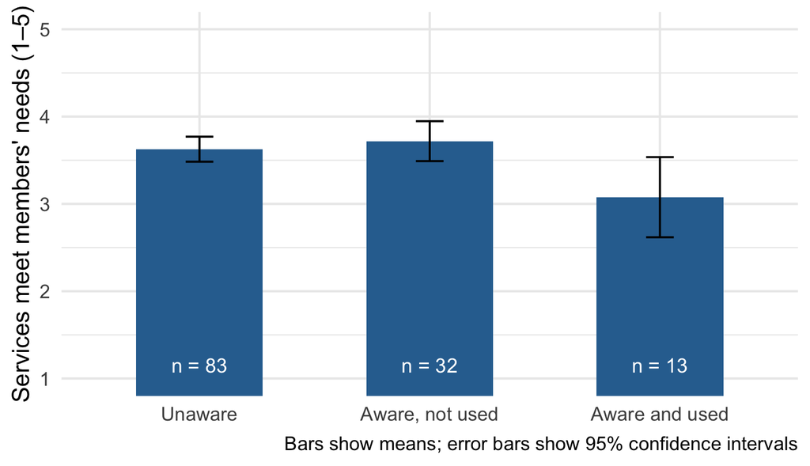

## H1: Do the groups differ?

Yes. Opinions on whether services meet members’ needs differ by awareness of the regular share account (*F*(2, 125) = 4.63, *p* = .011, η² = 0.07). Awareness explains about 6.9% of the variation, a small-to-medium effect.

The post hoc test shows where the difference lies:

| Comparison | Mean difference | 95% CI | Tukey p |
| --- | --- | --- | --- |
| Aware, not used-Unaware | 0.09 | [-0.23, 0.42] | .782 |
| Aware and used-Unaware | -0.55 | [-1.02, -0.08] | .017 |
| Aware and used-Aware, not used | -0.64 | [-1.16, -0.13] | .011 |

Users of the account differ from both other groups. The unaware and aware-but-not-used groups are indistinguishable.

## H1: Can we trust this result?

- **Equal variances:** the spread is similar across groups (Levene, *p* = .917).
- **Normality:** residuals are not normal (Shapiro–Wilk *W* = 0.88, *p* < .001), which is expected for 1–5 ratings. With 128 respondents, ANOVA is usually robust to this, but the smallest group is only 13.
- **Robustness checks agree:** Welch’s ANOVA (*F*(2, 29.7) = 3.62, *p* = .039) and the Kruskal–Wallis test (χ²(2) = 7.11, *p* = .029) both reach the same conclusion.

The significant result does not depend on the equal-variance and normality assumptions.

## H1: Conclusion

**H1 is supported**: awareness of the regular share account is related to opinions about whether services meet members’ needs.

- The relationship is **not** “more awareness, more satisfaction”. Awareness alone changes nothing: unaware members and aware non-users look the same.
- The gap appears only for **members who use the account**, who are the least positive.
- Only 13 members are in that group, so this should be treated as a lead to follow up (for example, what do regular share account holders feel is missing?), not as a firm conclusion.

## H2: Why a paired-samples *t*-test?

- **The same member answers both questions** (Q8r and Q30), so the two scores are linked within each person. They are not two independent groups.
- The test works on each member’s **difference score** (Q8r − Q30) and asks whether the average difference is different from zero.
- Both variables are treated as interval, 1–5 scales. Only members who answered both questions are included (*n* = 107; 21 members with no Q8r answer were excluded).

## H2: Two views of the loan rates

| Variable | n | Mean | SD |
| --- | --- | --- | --- |
| Opinion on loan rates charged (Q8r; 1 = very low, 5 = very high) | 107 | 3.14 | 0.76 |
| Agree CU loan rates are lower than others (Q30; 1–5) | 107 | 3.06 | 0.92 |

On average, members see the loan rates as **about average** (Q8r *M* = 3.14) and are **uncertain** whether those rates are lower than at other institutions (Q30 *M* = 3.06). The two averages are almost identical.

## H2: The difference is essentially zero

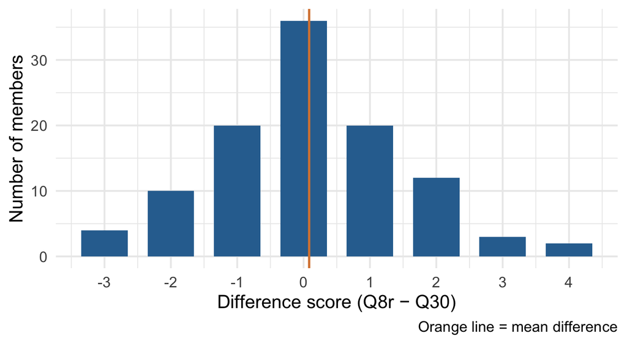

## H2: Do the two opinions differ?

No. Members’ average opinion of the loan rates does not differ from their average agreement that the rates are lower than competitors’ (*t*(106) = 0.60, *p* = .549). The mean difference is 0.08 scale points (95% CI [-0.19, 0.36]), a negligible effect (*d*<sub>z</sub> = 0.06).

- 37 members rated Q8r higher, 34 rated Q30 higher, and 36 gave identical answers.
- Checks: difference scores are not normal (Shapiro–Wilk *p* < .001), but the Wilcoxon signed-rank test agrees (*p* = .603).

## H2: Conclusion

**H2 is supported**: there is no detectable difference between the two opinions.

- The two scores are **negatively correlated** (*r* = -0.49). Members who think the rates are high tend to disagree that they are lower than elsewhere, which is consistent. The paired test only compares the *averages*, which happen to match.
- Failing to find a difference does not prove there is none. The confidence interval shows any true difference is likely smaller than about 0.4 scale points.
- The two questions use different anchors (very low–very high versus disagree–agree), so the equal averages should be read loosely.

## Summary of results

| Hypothesis | Test | Result | Conclusion |
| --- | --- | --- | --- |
| H1 | One-way ANOVA | *F*(2, 125) = 4.63, *p* = .011, η² = 0.07 | Supported. Users of the regular share account are less positive than the other two groups |
| H2 | Paired-samples *t*-test | *t*(106) = 0.60, *p* = .549, *d*<sub>z</sub> = 0.06 | Supported. No difference between the two loan-rate opinions |

## Appendix

**Links**

- GitHub repository: https://github.com/espinacecilia-design/6500/tree/main/IC10-case31
- GitHub Pages (published report): https://espinacecilia-design.github.io/6500/IC10-case31/IC_Case31_H1-H2_Summary_Cecilia_Espina.html

**Notes on method**

- Data: cleaned SPSS file `Case31_Data_efcu_4.sav` (N = 128); recoded variables Q13r and Q8r follow the Module 10 data preparation. “No opinion” / blank answers are system-missing in Q8r (21 members), so H2 uses the 107 members who answered both Q8r and Q30.
- Likert items (Q33, Q8r, Q30) are treated as interval scales, as in the Data Analysis Table. Effect sizes: η² (H1) and Cohen’s *d*<sub>z</sub> (H2).
- H1 post hoc comparisons use Tukey’s HSD. Robustness checks: Levene’s test (median-centered), Welch’s ANOVA, Kruskal–Wallis, and the Wilcoxon signed-rank test for H2.
- Analysis in R (`aov`, `TukeyHSD`, `t.test`, `car::leveneTest`); the numbers on these slides are calculated from the data when the file is rendered.